# Упражнение 3

Берлина М.

April 13, 2018

Цель: исследовать набор данных “Boston” с помощью линейной регрессионной модели. Задействовав регрессоры “zn”, “rm” и “chas”, сделать выводы о пригодности модели для прогноза.Сравнить с методом k ближайших соседей по MSE на тестовой выборке.

## Описание переменных

Набор данных `Boston` содержит переменные:

*`crim` - количество преступлений на душу населения в пригороде;* `zn` - доля спальных районов размером свыше 25 000 кв. футов; *`rm` - среднее количество комнат на одного жителя;* `chas` - находится на берегу реки Чарльз (1 - находится, 0 - нет) Размерность обучающей выборки: n=430 строк, p=3 объясняющих переменных. Зависимая переменная - `crim`.

```
##        zn              rm        chas         crim
##  Min.   : 0.00   Min.   :3.561   0:400   Min.   : 0.00632
##  1st Qu.: 0.00   1st Qu.:5.889   1: 30   1st Qu.: 0.08204
##  Median : 0.00   Median :6.214           Median : 0.25278
##  Mean   :11.52   Mean   :6.280           Mean   : 3.21937
##  3rd Qu.:16.25   3rd Qu.:6.628           3rd Qu.: 3.43597
##  Max.   :95.00   Max.   :8.780           Max.   :51.13580
```

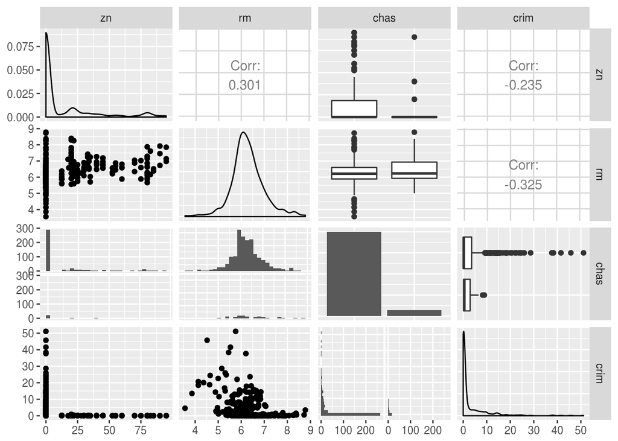

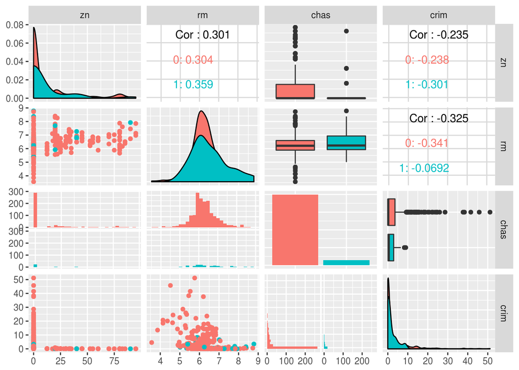

## Модели:

```
##
## Call:
## lm(formula = crim ~ . + chas:rm + chas:zn, data = df.train)
##
## Residuals:
##    Min     1Q Median     3Q    Max
## -7.284 -3.748 -1.654  1.565 45.800
##
## Coefficients:
##               Estimate Std. Error t value Pr(>|t|)
## (Intercept)  22.385528   2.955746   7.574 2.30e-13 ***
## zn           -0.043782   0.014022  -3.122  0.00192 **
## rm           -2.961557   0.476672  -6.213 1.24e-09 ***
## chas1       -21.028605   9.204598  -2.285  0.02283 *
## rm:chas1      3.084580   1.434753   2.150  0.03213 *
## zn:chas1      0.003887   0.063437   0.061  0.95117
## ---
## Signif. codes:  0 '***' 0.001 '**' 0.01 '*' 0.05 '.' 0.1 ' ' 1
##
## Residual standard error: 6.222 on 424 degrees of freedom
## Multiple R-squared:  0.1387, Adjusted R-squared:  0.1286
## F-statistic: 13.66 on 5 and 424 DF,  p-value: 2.249e-12
```

Совместное влияние zn и chas исключаем, так как параметр статистически незначим:

```
##
## Call:
## lm(formula = crim ~ . + chas:rm, data = df.train)
##
## Residuals:
##    Min     1Q Median     3Q    Max
## -7.287 -3.746 -1.662  1.567 45.801
##
## Coefficients:
##              Estimate Std. Error t value Pr(>|t|)
## (Intercept)  22.39557    2.94774   7.598 1.94e-13 ***
## zn           -0.04359    0.01366  -3.191  0.00152 **
## rm           -2.96352    0.47504  -6.238 1.07e-09 ***
## chas1       -21.19720    8.77351  -2.416  0.01611 *
## rm:chas1      3.11561    1.34084   2.324  0.02062 *
## ---
## Signif. codes:  0 '***' 0.001 '**' 0.01 '*' 0.05 '.' 0.1 ' ' 1
##
## Residual standard error: 6.215 on 425 degrees of freedom
## Multiple R-squared:  0.1387, Adjusted R-squared:  0.1306
## F-statistic: 17.11 on 4 and 425 DF,  p-value: 5.042e-13
```

В данной модели все объясняющие переменные статистически значимые, поэтому мы выбираем её как окончательную Проверим её остатки:

```
##
##  studentized Breusch-Pagan test
##
## data:  model.2
## BP = 19.095, df = 4, p-value = 0.0007528
```

```
##
##  Durbin-Watson test
##
## data:  model.2
## DW = 1.899, p-value = 0.1477
## alternative hypothesis: true autocorrelation is greater than 0
```

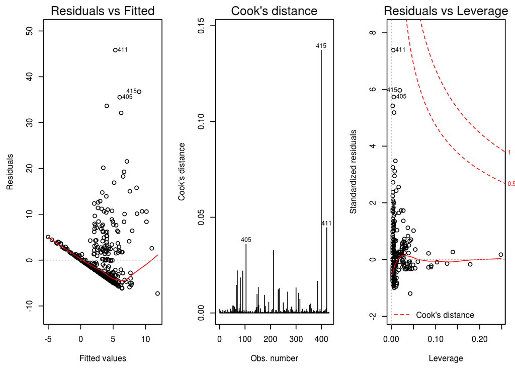

В данной модели нет автокорреляции остатков, но присутствует гетероскедастичность и влиятельные наблюдения.

# Сравнение с kNN

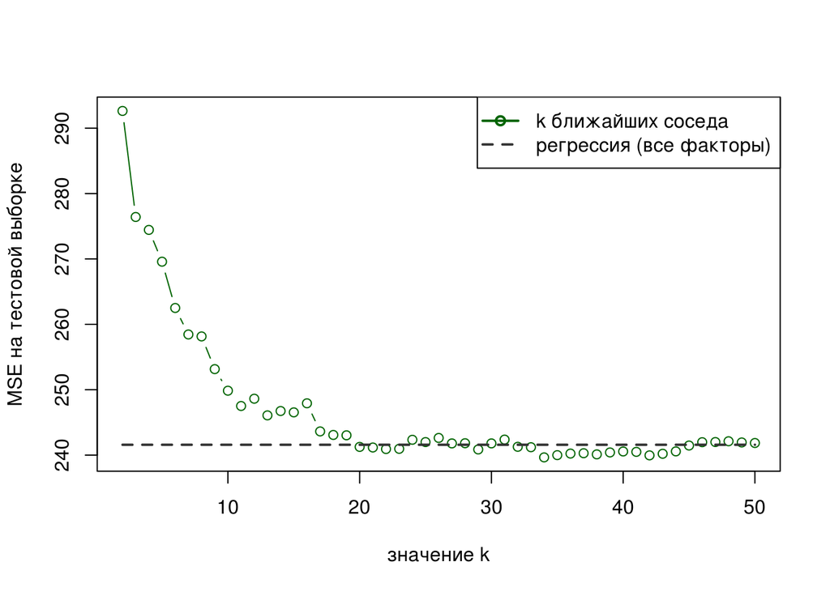

Как мы можем видеть по графику, ошибка регрессии на тестовой выборке приблизительно совпадает с ошибкой метода k ближайших соседей при k больше 16. Ошибка метода k ближайших соседей практически не меняется при всех k больше 16.